# Data Exploration

Kathy Lin

March 27, 2018

First we will import the necessary packages for exploratory analysis.

Given these packages, we first do some missing value analysis and then we begin by trying to produce univariate graphs of the variables in our dataset over time. Note we’ve converted the song duration from ms to minutes

```
## Skim summary statistics
##  n obs: 5100
##  n variables: 24
##
## Variable type: character
##            variable missing complete    n min  max empty n_unique
##              artist       0     5100 5100   1   89     0     2473
##              lyrics       0     5100 5100   0 5760   187     4634
##        release_date       0     5100 5100   0   10   337     1613
##                song       0     5100 5100   1   65     0     4583
##  spotify_album_name       0     5100 5100   0  109   337     3218
##      spotify_artist       0     5100 5100   0   56   337     1867
##        spotify_name       0     5100 5100   0  122   337     4412
##
## Variable type: integer
##  variable missing complete    n   mean    sd   p0     p25 median     p75
##      rank       0     5100 5100   50.5 28.87    1   25.75   50.5   75.25
##      year       0     5100 5100 1990   14.72 1965 1977    1990   2003
##  p100     hist
##   100 ▇▇▇▇▇▇▇▇
##  2015 ▇▇▇▇▇▇▇▇
##
## Variable type: numeric
##          variable missing complete    n       mean        sd          p0
##      acousticness     337     4763 5100      0.23      0.24      1.2e-05
##      danceability     337     4763 5100      0.63      0.15      0.13
##       duration_ms     337     4763 5100 241145.63  61486.57  78200
##            energy     337     4763 5100      0.63      0.19      0.02
##          explicit     337     4763 5100      0.093     0.29      0
##  instrumentalness     337     4763 5100      0.023     0.11      0
##               key     337     4763 5100      5.27      3.57      0
##          liveness     337     4763 5100      0.18      0.15      0.019
##          loudness     337     4763 5100     -8.35      3.49    -25.49
##              mode     337     4763 5100      0.69      0.46      0
##        popularity     337     4763 5100     53.36     14.56      0
##       speechiness     337     4763 5100      0.069     0.073     0.022
##             tempo     337     4763 5100    119.22     27.22     51.32
##    time_signature     337     4763 5100      3.97      0.24      0
##           valence     337     4763 5100      0.61      0.24      0.037
##         p25       median          p75       p100     hist
##       0.038      0.14         0.37          0.98 ▇▃▂▂▁▁▁▁
##       0.53       0.64         0.73          0.99 ▁▁▂▅▇▇▃▁
##  205680     235933       268640       1561133    ▇▃▁▁▁▁▁▁
##       0.5        0.65         0.79          1    ▁▁▂▆▇▇▇▃
##       0          0            0             1    ▇▁▁▁▁▁▁▁
##       0          5.1e-06      0.00046       0.96 ▇▁▁▁▁▁▁▁
##       2          5            8            11    ▇▃▃▃▂▆▃▅
##       0.084      0.12         0.22          1    ▇▃▂▁▁▁▁▁
##     -10.63      -7.81        -5.64         -1.1  ▁▁▁▂▅▇▇▂
##       0          1            1             1    ▃▁▁▁▁▁▁▇
##      44         55           65            87    ▁▁▂▅▇▇▆▁
##       0.032      0.041        0.066         0.74 ▇▁▁▁▁▁▁▁
##      98.99     117.99       133.17        210.75 ▁▃▇▇▅▂▁▁
##       4          4            4             5    ▁▁▁▁▁▁▇▁
##       0.42       0.63         0.81          0.99 ▂▃▅▆▇▇▇▇
```

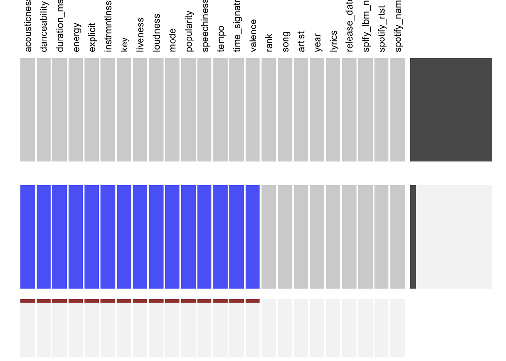

There seems to be 337 songs that have 15 continuous features such as acousticness, danceability, duration, energy, explicitness, etc. missing at the same time. These songs will be removed for univariate analysis. To begin the univariate analysis, we converted duration_ms to duration in minutes for ease of comprehension.